# R Machine Learning

This is to try and predict the manner in which an exercise was done.

Using different machine learning tools that R provides, I used two different algorigthms that both had high predictive abilities.

First loading and cleaning the data was neccessary.

```r
library(caret)
library(dplyr)
library(randomForest)
library(e1071)
setwd("C:/Users/Zhao/Downloads")
data <- read.csv("pml-training.csv", na.strings = c("NA",""))
data <- data[ , colSums(is.na(data)) == 0]
data <- subset(data, select = -(1:6))
```

I broke the data into training and testing sections.

```r
inTrain <- createDataPartition(data$classe, p=0.6, list=F)
training <- data[inTrain,]
testing <- data[-inTrain,]
```

Then created a random forest model. The formula used with the caret package took a long time to load. So, I used the randomForest formula since the compute time was much quicker. We can see that the first several variables carry most of the predictive ability

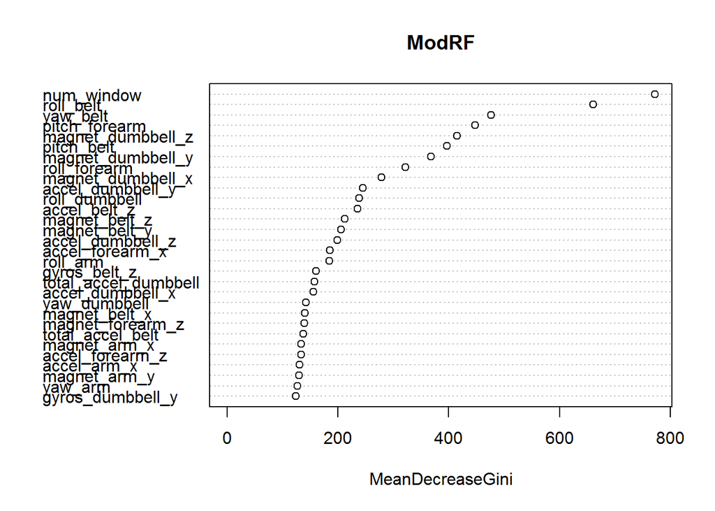

```r
ModRF <- randomForest(classe ~ ., data=training)
varImpPlot(ModRF)
```

```r
testRF <- predict(ModRF,testing)
confusionMatrix(testRF, testing$classe)
```

```
## Confusion Matrix and Statistics
##
##           Reference
## Prediction    A    B    C    D    E
##          A 2232    2    0    0    0
##          B    0 1516    6    0    0
##          C    0    0 1361   10    0
##          D    0    0    1 1275    2
##          E    0    0    0    1 1440
##
## Overall Statistics
##
##                Accuracy : 0.9972
##                  95% CI : (0.9958, 0.9982)
##     No Information Rate : 0.2845
##     P-Value [Acc > NIR] : < 2.2e-16
##
##                   Kappa : 0.9965
##  Mcnemar's Test P-Value : NA
##
## Statistics by Class:
##
##                      Class: A Class: B Class: C Class: D Class: E
## Sensitivity            1.0000   0.9987   0.9949   0.9914   0.9986
## Specificity            0.9996   0.9991   0.9985   0.9995   0.9998
## Pos Pred Value         0.9991   0.9961   0.9927   0.9977   0.9993
## Neg Pred Value         1.0000   0.9997   0.9989   0.9983   0.9997
## Prevalence             0.2845   0.1935   0.1744   0.1639   0.1838
## Detection Rate         0.2845   0.1932   0.1735   0.1625   0.1835
## Detection Prevalence   0.2847   0.1940   0.1747   0.1629   0.1837
## Balanced Accuracy      0.9998   0.9989   0.9967   0.9955   0.9992
```

I repeated the model, testing, and confusion matrix for a support vector machine. This model was less accurate than the orgininal.

```r
ModSV <- svm(classe ~ ., data=training)
testSV <- predict(ModSV,testing)
confusionMatrix(testSV, testing$classe)
```

```
## Confusion Matrix and Statistics
##
##           Reference
## Prediction    A    B    C    D    E
##          A 2205  104    2    3    1
##          B    5 1363   62    0   18
##          C   22   47 1283  137   28
##          D    0    1   18 1144   44
##          E    0    3    3    2 1351
##
## Overall Statistics
##
##                Accuracy : 0.9363
##                  95% CI : (0.9306, 0.9416)
##     No Information Rate : 0.2845
##     P-Value [Acc > NIR] : < 2.2e-16
##
##                   Kappa : 0.9193
##  Mcnemar's Test P-Value : < 2.2e-16
##
## Statistics by Class:
##
##                      Class: A Class: B Class: C Class: D Class: E
## Sensitivity            0.9879   0.8979   0.9379   0.8896   0.9369
## Specificity            0.9804   0.9866   0.9639   0.9904   0.9988
## Pos Pred Value         0.9525   0.9413   0.8457   0.9478   0.9941
## Neg Pred Value         0.9951   0.9758   0.9866   0.9786   0.9860
## Prevalence             0.2845   0.1935   0.1744   0.1639   0.1838
## Detection Rate         0.2810   0.1737   0.1635   0.1458   0.1722
## Detection Prevalence   0.2951   0.1846   0.1933   0.1538   0.1732
## Balanced Accuracy      0.9842   0.9422   0.9509   0.9400   0.9678
```

Seeing as how the random forest model was much more accurate, I would use that to predict out of sample. I expect the out of sample error to be faily low (above 80% accuracy), but higher than the current error rate. Below, the model is used to predict the 20 different test cases. Seeing as how I expect this model to have a higher than 80% accuracy rate out of sample, these should all be correct with the possibility of possibly one wrong.

```r
testdata <- read.csv("pml-testing.csv", na.strings = c("NA",""))
data <- data[ , colSums(is.na(data)) == 0]
data <- subset(data, select = -(1:6))
predict(ModRF,testdata)
```

```
##  1  2  3  4  5  6  7  8  9 10 11 12 13 14 15 16 17 18 19 20
##  B  A  B  A  A  E  D  B  A  A  B  C  B  A  E  E  A  B  B  B
## Levels: A B C D E
```